# 326.212 Homework 1

### Textbook 3.9.1

#### Problem 1. Turn a stacked bar chart into a pie chart using coord_polar().

stacked bar chart는 다음과 같이 데이터의 값이 쌓여있는 chart를 말한다.

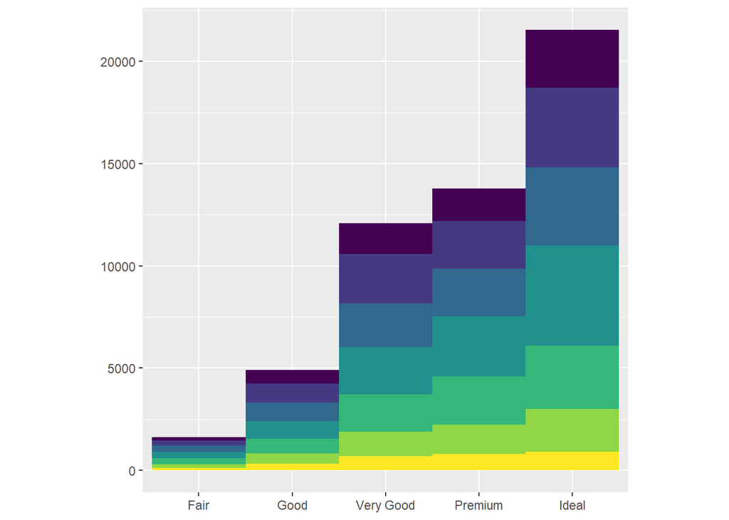

```r
ggplot(data = diamonds) + geom_bar(mapping = aes(x = cut, fill = color), show.legend = FALSE, width = 1) + theme(aspect.ratio = 1) + labs(x = NULL, y = NULL)
```

이 chart를 pie chart로 바꾸는것은 coord_polar()를 통해 좌표계를 극좌표계로 바꿔주면 된다.

다음과 같이 실행하면 된다.

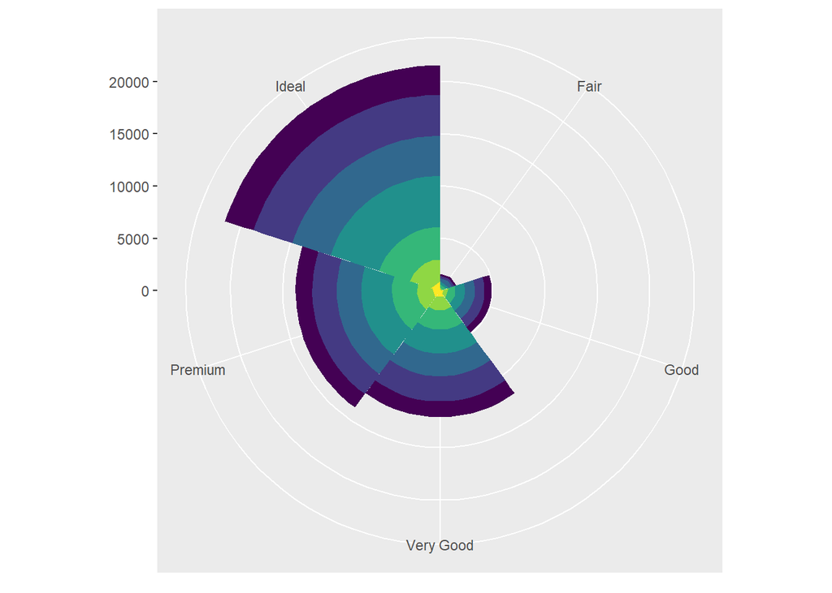

```r
ggplot(data = diamonds) + geom_bar(mapping = aes(x = cut, fill = color), show.legend = FALSE, width = 1) + theme(aspect.ratio = 1) + labs(x = NULL, y = NULL) + coord_polar()
```

#### Problem 4. What does the plot below tell you about the relationship between city and highway mpg? Why is coord_fixed() important? What does geom_abline() do?

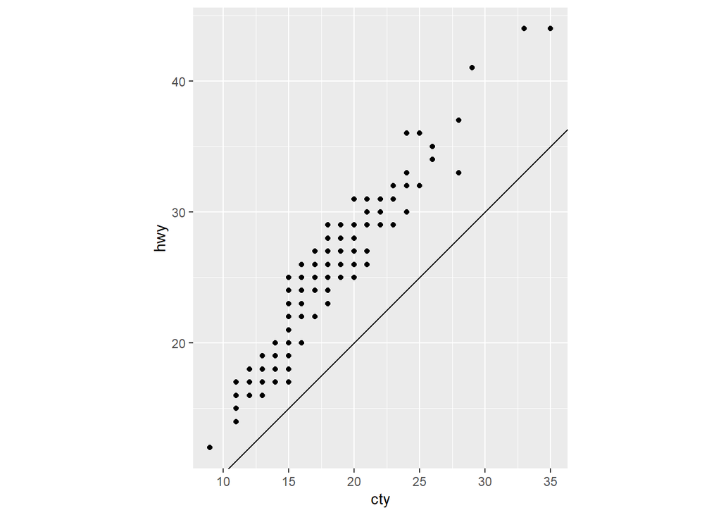

```r
ggplot(data = mpg, mapping = aes(x = cty, y = hwy)) +
  geom_point() +
  geom_abline() +
  coord_fixed()
```

위 plot은 mpg에서 city와 highway 간에 대략적으로 일차함수적인 비례관계가 존재함을 보이고 있다.

coord_fixed()의 역할은 ratio argument로 y축의 비율/x축의 비율을 인자로 받아서 그에 맞게 그래프를 그려주는 역할을 하고, (default ratio는 1) geom_abline()은 y절편, 기울기등을 받아서 추세선을 그려주는 역할을 한다. (default y절편은 0, 기울기는 1)

coord_fixed()를 이용해 x축과 y축의 비율이 정확하게 유지되지 않는다면, 데이터를 해석하는데 왜곡이 일어날 수 있고, geom_abline()으로 추세선을 그렸을때 추세선의 기울기가 정확하지 않게 표현될 수 있으므로, coord_fixed()를 이용해서 x축과 y축의 비율을 일정하게 유지해주는것이 중요하다.

### Textbook 6.3

#### Problem 2. What other common mistakes will RStudio diagnostics report? Read https://support.rstudio.com/hc/en-us/articles/205753617-Code-Diagnostics to find out.

RStidio diagnostics가 알려주는 흔한 오류들에는 여러가지가 있는데, 예를 들어 다음과 같은 것들이 존재한다.

1. 함수의 argument를 빼먹거나, 잘못된 argument를 집어넣거나, 필요 이상의 argument를 집어넣는 경우
2. scope에 variable의 정의가 없는경우.
3. 변수가 선언되었지만 쓰이지 않은경우.

등이 존재한다.

### Textbook 28.2.1

#### Problem 1. Create one plot on the fuel economy data with customised title, subtitle, caption, x, y, and colour labels.

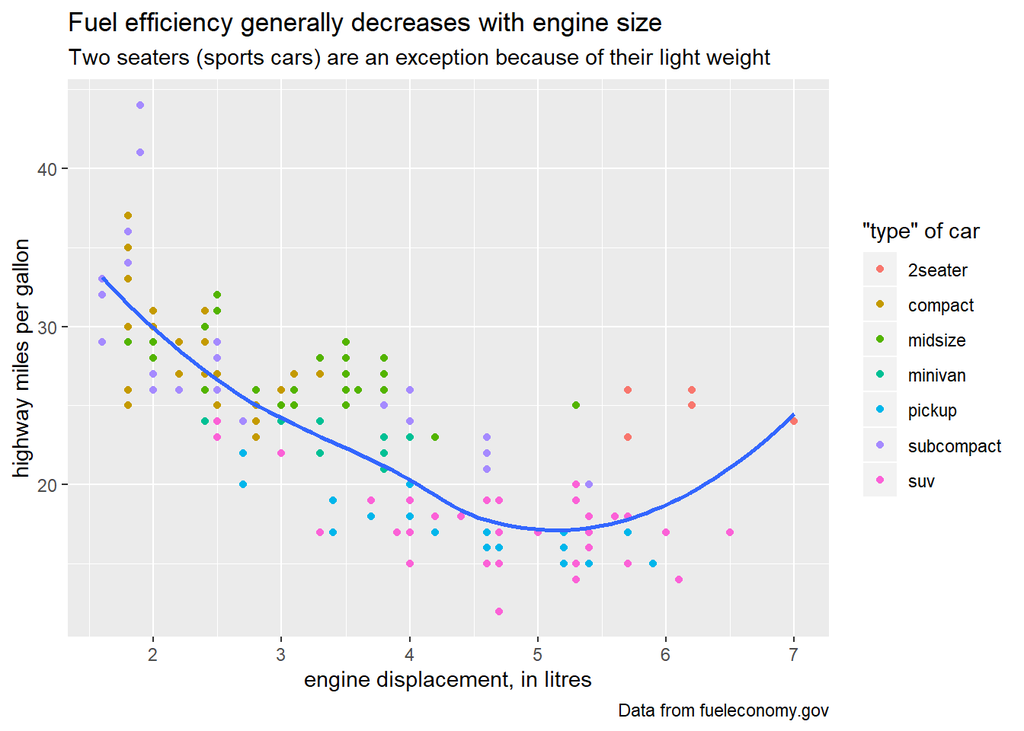

```r
ggplot(mpg, aes(displ, hwy)) +
  geom_point(aes(colour = class)) +
  geom_smooth(se = FALSE) +
  labs(
    title = "Fuel efficiency generally decreases with engine size",
    subtitle = "Two seaters (sports cars) are an exception because of their light weight",
    caption = "Data from fueleconomy.gov",
    x = "engine displacement, in litres",
    y = "highway miles per gallon",
    colour = "\"type\" of car"
  )
```

### Textbook 28.4.4

#### Problem 4. Use override.aes to make the legend on the following plot easier to see.

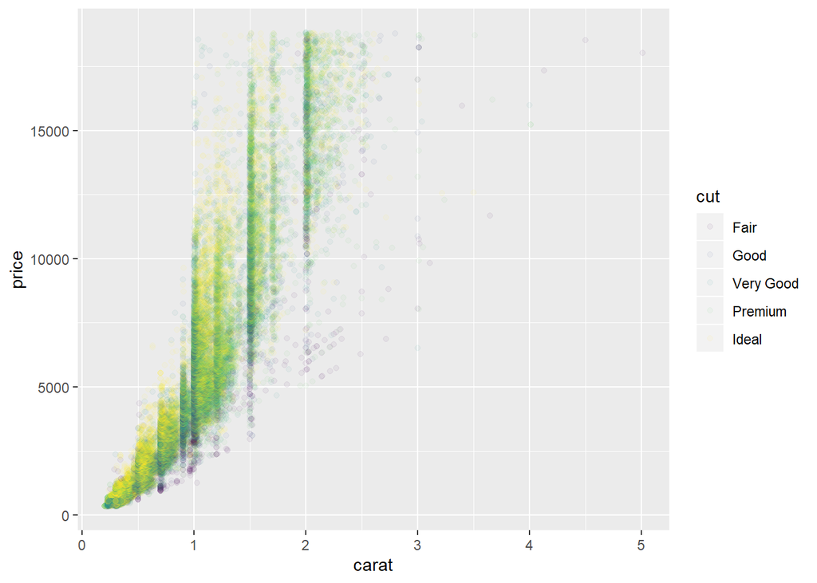

```r
ggplot(diamonds, aes(carat, price)) +
  geom_point(aes(colour = cut), alpha = 1/20)
```

아래와 같이 고치면 된다.

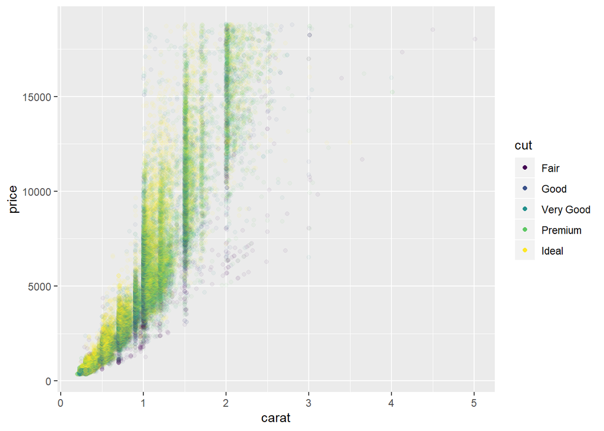

```r
ggplot(diamonds, aes(carat, price)) +
  geom_point(aes(colour = cut), alpha = 1/20) +
  guides(color = guide_legend(override.aes = list(alpha = 1)))
```

### Extra questions

#### Problem 1. Write an R script that when run performs the following:

##### assign $x=5$ and $y=6$

```r
x <- 5
y <- 6
```

##### calculate $\ln(x+y)$

```r
(log(x + y))
```

```
## [1] 2.397895
```

##### calculate $\log_{10}(xy/2)$

```r
(log10(x*y/2))
```

```
## [1] 1.176091
```

##### calculate $\sqrt[3]{x}+2\sqrt[4]{y}$

```r
(x^(1/3)+2*y^(1/4))
```

```
## [1] 4.840145
```

##### calculate $10^{x−y}+e^{x+y}$

```r
(10^(x-y)+exp(x+y))
```

```
## [1] 59874.24
```

#### Problem 2. Why does the following code not work?

```r
my_variable <- 123
  my_varlable
```

my_variable이라는 변수에 123이라는 수를 할당하고나서, 다음에 호출하는 변수는 my_varlable이라는, 선언한적이 없는 다른 변수이므로 오류가 발생한다. 이를 작동시키기 위해선

```r
my_variable <- 123
  my_variable
```

```
## [1] 123
```

과 같이 코드를 고쳐야한다.